# Multivariate Conditional Distributions

## From last time: MVN with MLE and Method of Moments

One can estimate \(\hat{F}_{\boldsymbol{X}}(\boldsymbol(x))\) with maximum likelihood or method of moments.

\[ \hat{\boldsymbol{\mu}} = \left[\begin{array}{c} \text{sample mean of variable 1} \\ \text{sample mean of variable 2} \\ \vdots \\ \text{sample mean of variable } p \end{array}\right] \\ \hat{\boldsymbol{\Sigma}} = \text{sample variance-covariance} \]

## From last time: MVN with MLE and Method of Moments

```r
Hmisc::getHdata(nhgh)
d1 <- nhgh %>%
  filter(sex == "male") %>%
  filter(age > 18) %>%
  select(arml, leg) %>%
  filter(complete.cases(arml, leg))
d1 %>%
  plot(col = "#00000020", pch = 16)
```

## From last time: MVN with MLE and Method of Moments

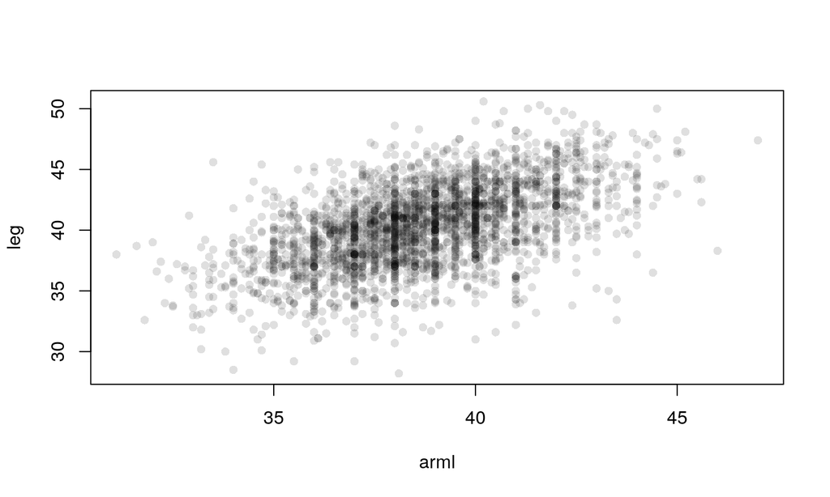

## From last time: MVN with MLE and Method of Moments

```r
mu_hat <- colMeans(d1)
sigma_hat <- var(d1)

limits <- d1 %>% sapply(range)
x <- seq(limits[1,1], limits[2,1],length = 50)
y <- seq(limits[2,1], limits[2,2],length = 50)
xy <- expand.grid(x = x, y = x, KEEP.OUT.ATTRS = FALSE)
density <- dmvnorm(xy, mean = mu_hat, sigma = sigma_hat)
z <- array(density, c(length(x), length(y)))
```

## From last time: MVN with MLE and Method of Moments

```r
plot(d1, col = "#00000020", pch = 16)
contour(
    x = x
  , y = x
  , z = z
  , add = TRUE
  , col = "navy"
  , lwd = 2
  , drawlabels = FALSE
)
```

## MVN with MLE and Method of Moments

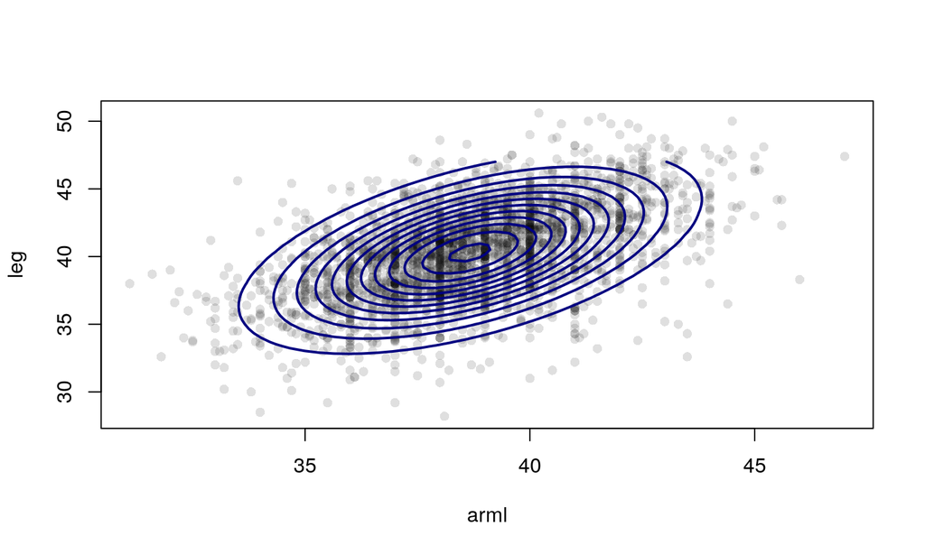

## From last time: MVN and prediction

> **Key question:** How can we use the joint distribution to make better predictions?

## From last time: MVN and prediction

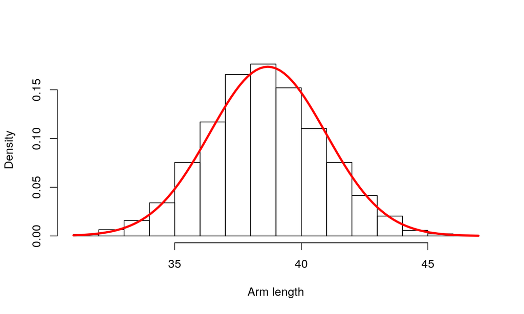

## From last time: MVN and prediction

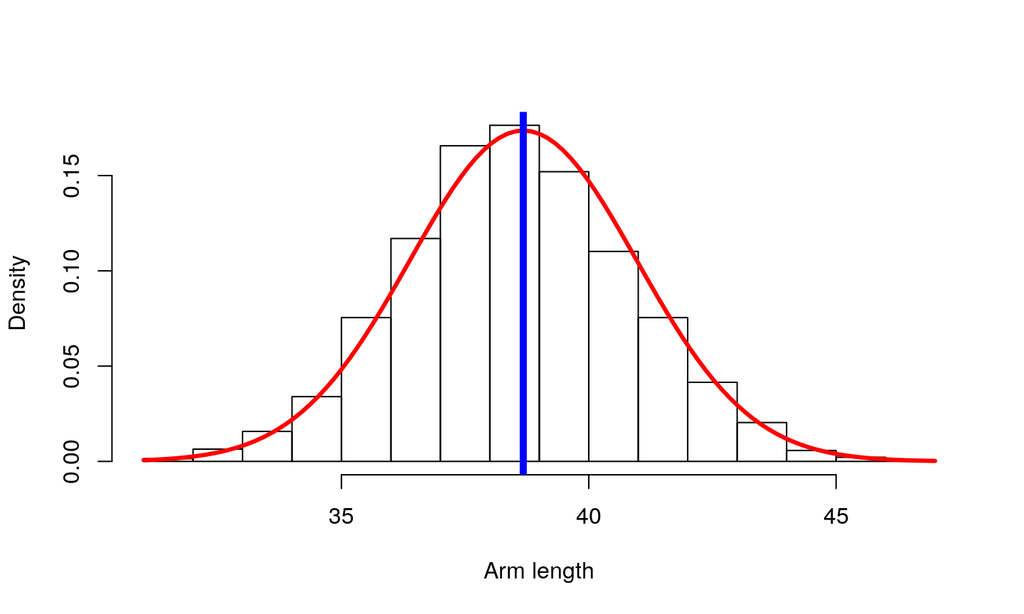

## Aside

Intuitively, most folks will choose the middle (blue line) value as the best prediction. Why? It is the value that, on average, minimizes the prediction error. The following is the mathematical statement of that idea.

> **Mean squared error (MSE)**: Let \[\text{error} = \text{predicted outcome} - \text{ outcome }, \] then \[ \text{MSE} = \frac{1}{n}\sum_{i=1}^N \left(\text{error}_i\right)^2. \] The MSE is commonly used to define “the best prediction model”; in such settings, the best prediction model is the one that minimized the MSE.

## Aside

There are other ways of defining “the best prediction model”.

> **Mean absolute error (MAE)**: Let \[\text{error} = \text{predicted outcome} - \text{ outcome }, \] then \[ \text{MAE} = \frac{1}{n}\sum_{i=1}^N \left|\text{error}_i\right| \]

## From last time: MVN and prediction

> **Thought experiment:** Which outcome will be easier to predict?

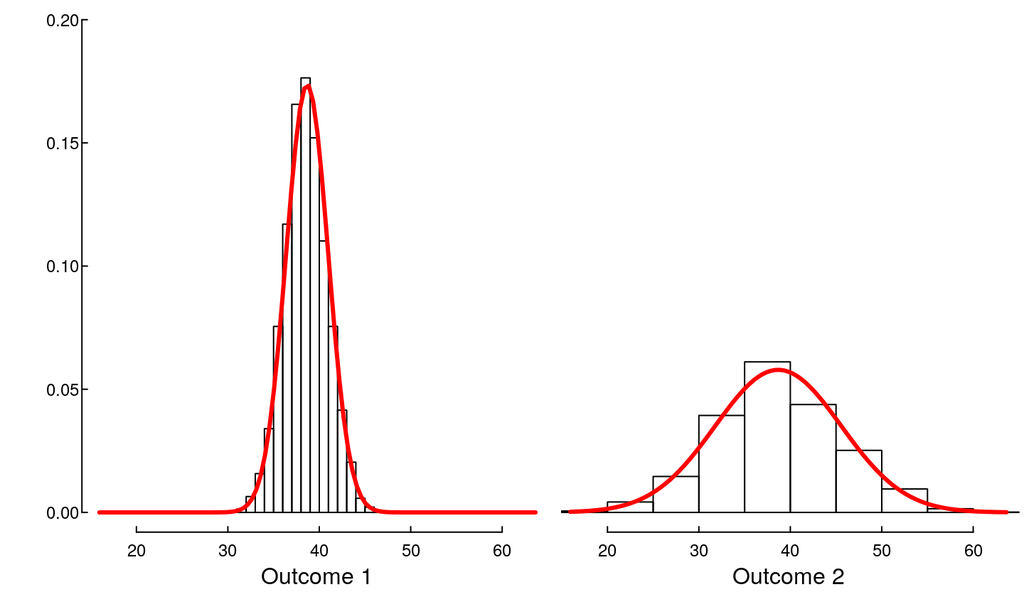

## From last time: MVN and prediction

> **Thought experiment:** Which outcome will be easier to predict?

The outcome with the smaller variance will have a smaller average prediction error.

## From last time: MVN and prediction

If we have the joint distribution, we can look at the **conditional** distribution of \[\text{leg} | \text{arml} = 40\\ \text{or} \\ \text{arml} | \text{leg} = 35 \]

## From last time: MVN and prediction

The conditional distribution is a slice of the joint distribution

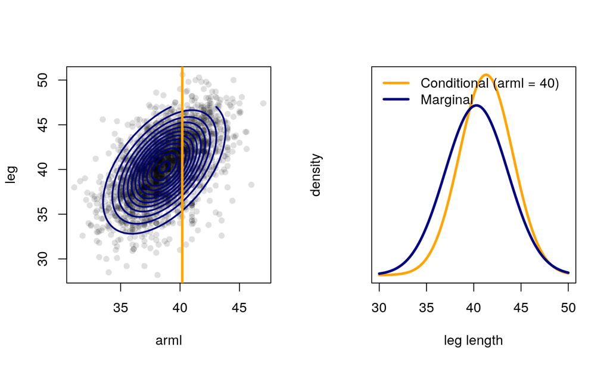

## MVN and prediction

Compare the variance of the conditional and unconditional distribution for different degrees of correlation.

## MVN and prediction

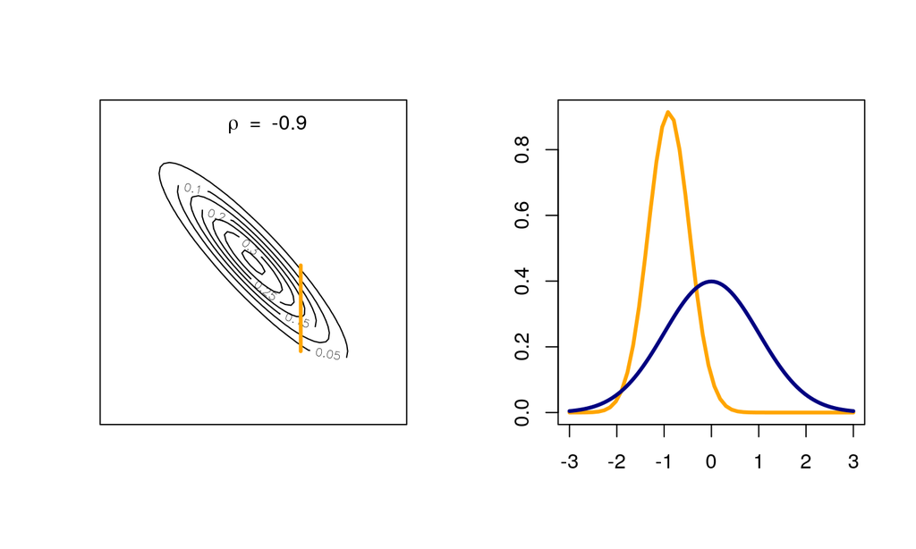

## MVN and prediction

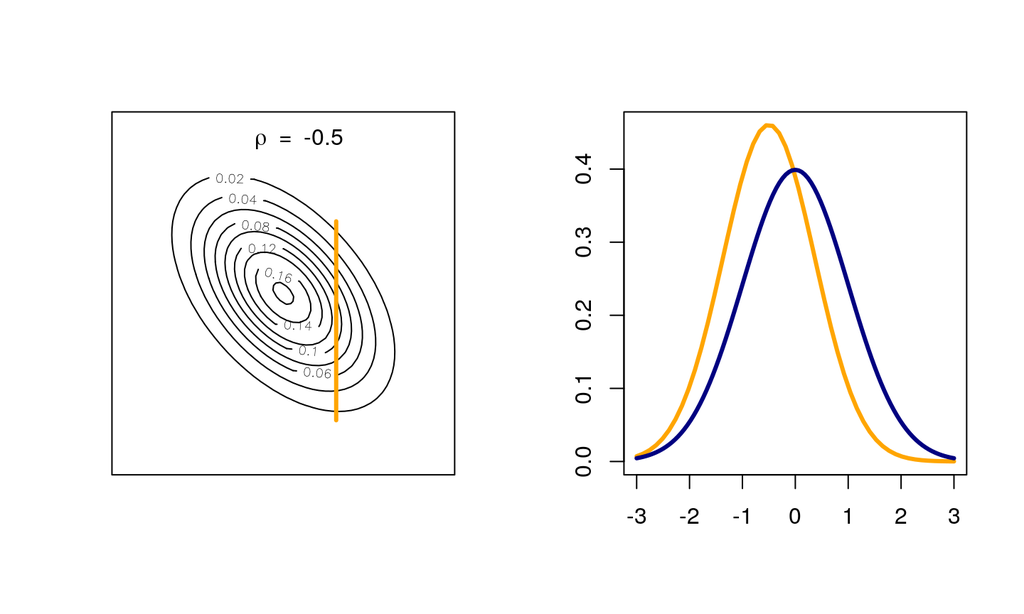

## MVN and prediction

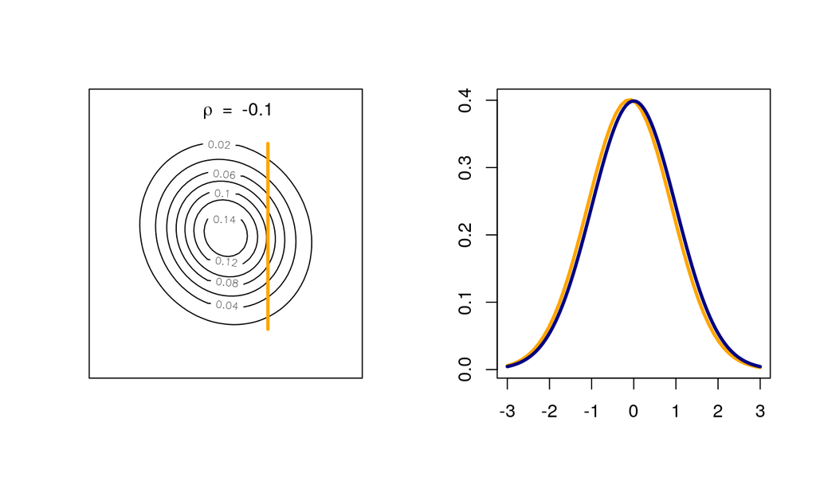

## MVN and prediction

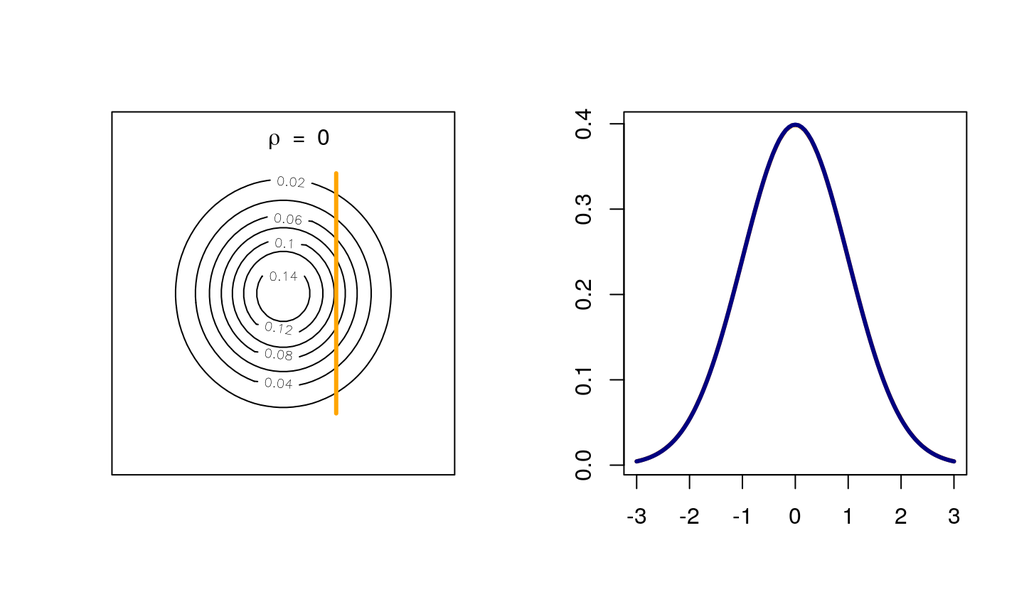

## MVN and prediction

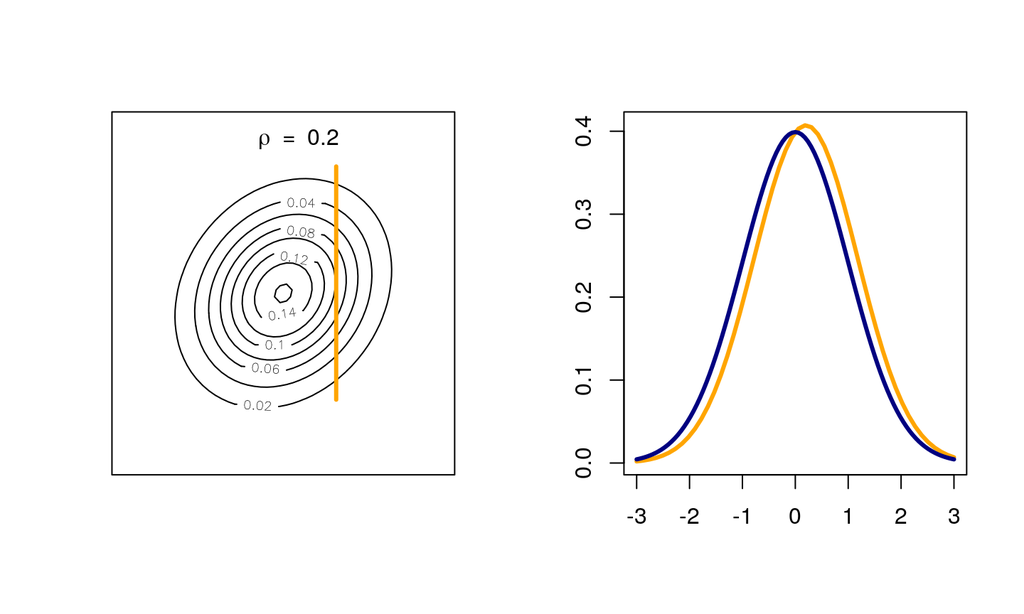

## Aside

A common measure of model predictive performance is \(R^2\). One way to motivate \(R^2\) is think about the variance of the prediction from the marginal model (blue distribution) and the variance from the conditional model (orange distribution).

\[R^2 \approx 1 - \frac{\text{variance of conditional model}}{\text{variance of marginal model}}\]

## Aside

Which model will have a \(R^2\) closer to 0?

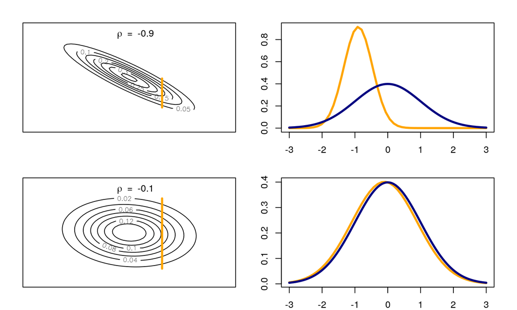

## Conditional distribution of MVN

\[ \text{If } \\ \boldsymbol{Y} = \left[\begin{array}{c} Y_1 \\ Y_2 \end{array}\right] \sim MVN\left(\boldsymbol{\mu} = \left[\begin{array}{c}\mu_1 \\ \mu_2 \end{array}\right], \Sigma = \left[\begin{array}{cc} \sigma^2_1 & \rho\sigma_1\sigma_2 \\ \rho\sigma_1\sigma_2 & \sigma^2_2 \end{array}\right] \right)\]

\[\text{Then }\\ Y_1|Y_2 = y_2 \sim N\left(\mu_1 + \frac{\sigma_1}{\sigma_2}\rho(y_2 - \mu_2), \text{var} = (1-\rho^2)\sigma^2_1\right)\]

## Conditional distribution of MVN

\[ \begin{align*} E\left[Y_1|Y_2 = y_2 \right] &= \mu_1 + \frac{\sigma_1}{\sigma_2}\rho(y_2 - \mu_2) \\ & = \underbrace{\mu_1 - \frac{\sigma_1}{\sigma_2}\rho}_{\beta_0} + \underbrace{\frac{\sigma_1}{\sigma_2}\rho}_{\beta_1}\ y_2 \\ & = \beta_0 + \beta_1 y_2 \end{align*} \]

## Conditional distribution of MVN and linear regression

In linear regression, rather than estimating the entire joint distribution (say \(\boldsymbol{Y} \sim MVN\left(\boldsymbol{\mu}, \Sigma \right)\)), one only estimates the conditional expectation and variance.

\[\begin{align*}E\left[Y_1|Y_2 = y_2 \right] &=\beta_0 + \beta_1\ y_2 \\ V\left[Y_1|Y_2 = y_2 \right] &= \sigma^2\end{align*}\]

## Linear regression allows for more flexible models of association

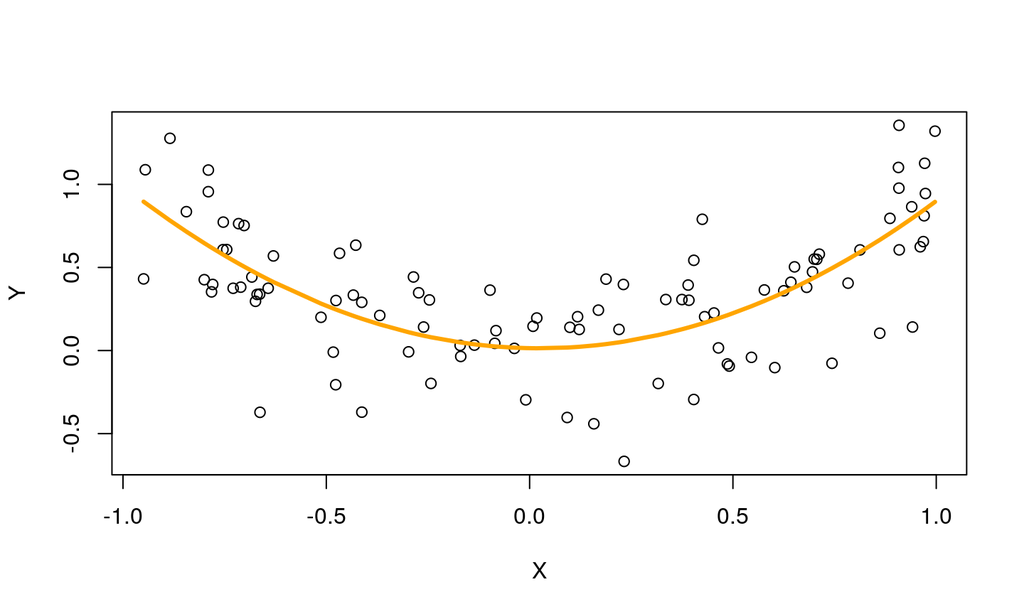

## Linear regression allows for more flexible models of association

Perhaps there is a non-linear relationship, which can be easily incorporated into the linear regression model.

\[\begin{align*}E\left[Y_1|Y_2 = y_2 \right] &=\beta_0 + \beta_1\ y_2 + \beta_2\ y_2^2 \\ V\left[Y_1|Y_2 = y_2 \right] &= \sigma^2\end{align*}\]